# Ejemplo_TEA ACM

Equipo 7. Manuel Rios, Adrian Vazquez, Abraham Nieto, Ricardo Lastra

24 de marzo de 2017

### Ejemplo en FACTOMINER con data set TEA ACM ó MCA

Datos

```r
# lCargamos paquetes
require(FactoMineR) #Deben de de intalar primero con install.packages("FactoMineR")  el paquete de FactoMine para ACM o  MCA
```

```r
require(ggplot2)
```

Para entender las variables elegidas, responden a las siguientes preguntas de un cuestionario realizado a 300 personas sobre su consumo de “Té”…el cuestionario es mas extenso…en el ejemplo solo se elige lo siguiente:

1.What kind of tea do you drink (black, green, flavored) 2.How do you drink it (alone, w/milk, w/lemon, other) 3.What kind of presentation do you buy (tea bags, loose tea, both) 4.Do you add sugar (yes, no) 5.Where do you buy it (supermarket, shops, both) 6.Do you always drink tea (always, not always)

```r
#  Cargamos data set
data(tea)
#  seleccionamos solo 6 variables de las 36 disponibles
newtea = tea[, c("Tea", "How", "how", "sugar", "where", "always")]
# revisamos datos
head(newtea)
```

```
##         Tea   How     how    sugar       where     always
## 1     black alone tea bag    sugar chain store Not.always
## 2     black  milk tea bag No.sugar chain store Not.always
## 3 Earl Grey alone tea bag No.sugar chain store Not.always
## 4 Earl Grey alone tea bag    sugar chain store Not.always
## 5 Earl Grey alone tea bag No.sugar chain store     always
## 6 Earl Grey alone tea bag No.sugar chain store Not.always
```

Numero de categorias por variable

```r
cats = apply(newtea, 2, function(x) nlevels(as.factor(x)))
cats
```

```
##    Tea    How    how  sugar  where always
##      3      4      3      2      3      2
```

### Aqui viene la magia que no entiendo mucho aun del ::FACTOMINER::

```r
# apply MCA
mca1 = MCA(newtea, graph = FALSE)

# Tabla de eigenvalores  y  % de varianza
mca1$eig
```

```
##        eigenvalue percentage of variance cumulative percentage of variance
## dim 1  0.27976178              15.259733                          15.25973
## dim 2  0.25774772              14.058967                          29.31870
## dim 3  0.22013794              12.007524                          41.32622
## dim 4  0.18792961              10.250706                          51.57693
## dim 5  0.16876495               9.205361                          60.78229
## dim 6  0.16368666               8.928363                          69.71065
## dim 7  0.15288834               8.339364                          78.05002
## dim 8  0.13838682               7.548372                          85.59839
## dim 9  0.11569167               6.310455                          91.90885
## dim 10 0.08612637               4.697802                          96.60665
## dim 11 0.06221147               3.393353                         100.00000
```

Coordenadas de columnas

```r
head(mca1$var$coord)
```

```
##                 Dim 1      Dim 2       Dim 3       Dim 4       Dim 5
## black      0.44584561  0.1434425  1.12721711  0.73788273  0.17249121
## Earl Grey -0.25030959  0.1114576 -0.48017120 -0.06982837 -0.07847201
## green      0.46415681 -0.9735173  0.28057503 -1.24625598  0.07214388
## alone     -0.02188719 -0.2511487  0.10325539 -0.45736660 -0.23317455
## lemon      0.68232208  0.4639225 -1.26750295  1.00191105 -1.17059696
## milk      -0.33098636  0.2285616  0.06944416  0.64061170  1.34608770
```

Coordenadas de filas

```r
head(mca1$ind$coord)
```

```
##        Dim 1      Dim 2      Dim 3       Dim 4      Dim 5
## 1 -0.3268523 -0.2902282  0.3811432  0.40596441 -0.2344112
## 2 -0.2691620 -0.1058693  0.7996894  0.55662973  0.4268537
## 3 -0.3911251 -0.2738513  0.2407184 -0.17603159 -0.3156732
## 4 -0.5462140 -0.3007284 -0.1898383  0.09543181 -0.3362276
## 5 -0.3386818 -0.2149876 -0.0324201 -0.37509336  0.2390809
## 6 -0.3911251 -0.2738513  0.2407184 -0.17603159 -0.3156732
```

Graficamos como en clase

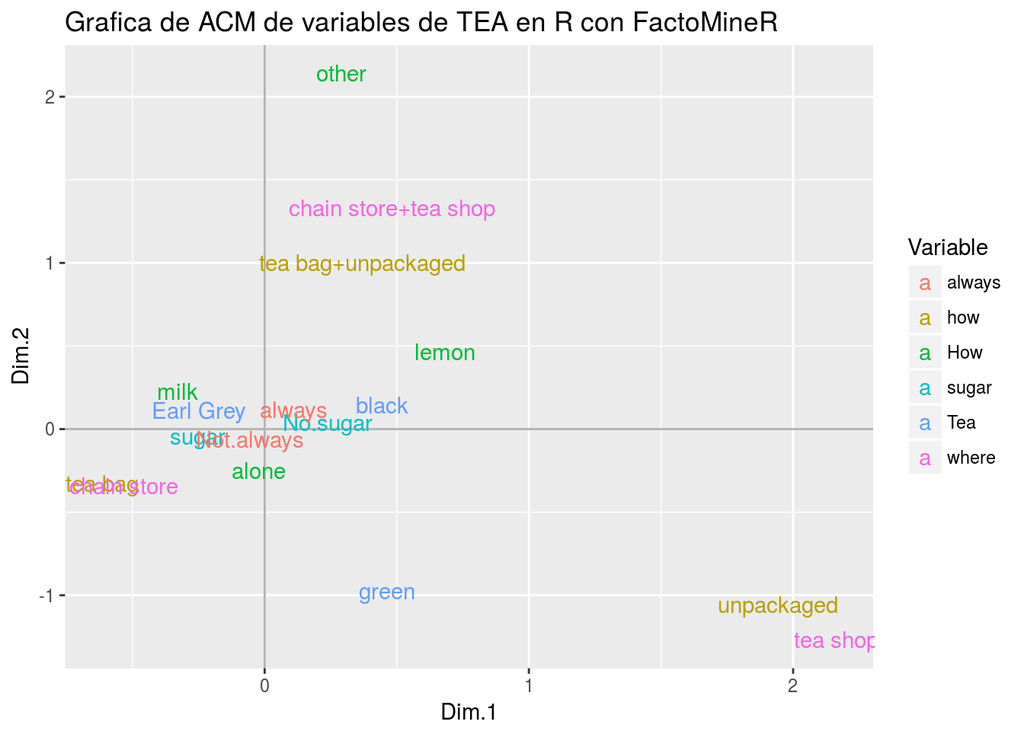

```r
# Graficamos con Data.Frame
mca1_vars_df = data.frame(mca1$var$coord, Variable = rep(names(cats),
    cats))
mca1_obs_df = data.frame(mca1$ind$coord)

# Grafica de las categorias de las variables
ggplot(data = mca1_vars_df, aes(x = Dim.1, y = Dim.2, label = rownames(mca1_vars_df))) +
    geom_hline(yintercept = 0, colour = "gray70") + geom_vline(xintercept = 0,
    colour = "gray70") + geom_text(aes(colour = Variable)) + ggtitle("Grafica de ACM de variables de TEA en R con FactoMineR")
```

Le hechamos ganitas a la grafica… JOJOJOJOJO

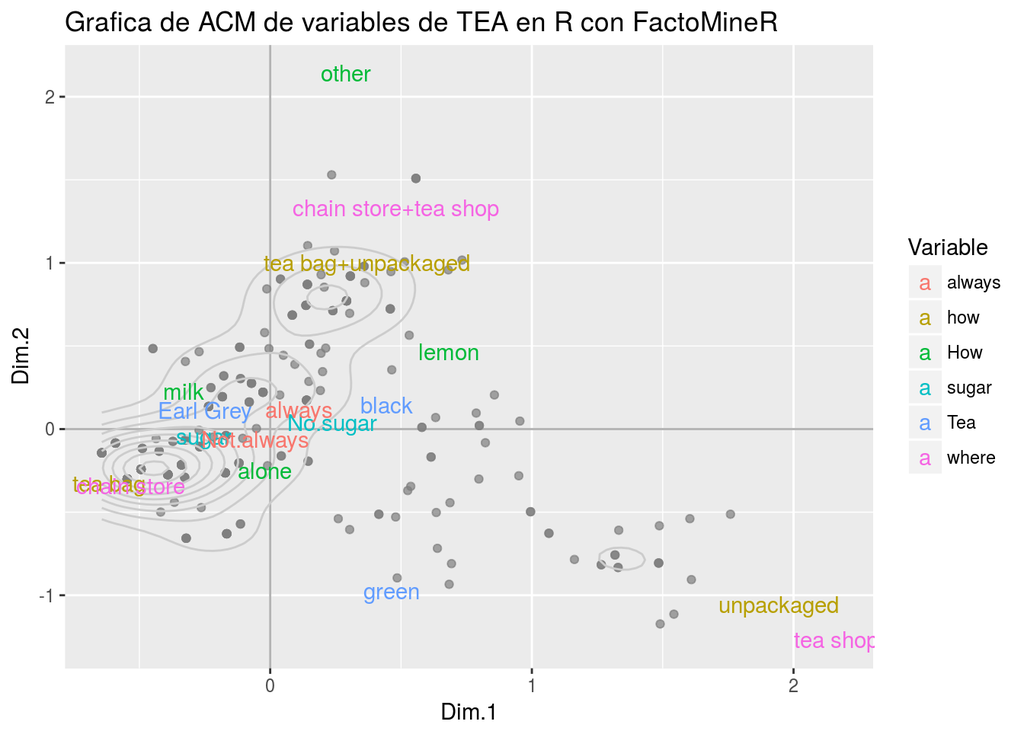

```r
# Observaciones y categorias
ggplot(data = mca1_obs_df, aes(x = Dim.1, y = Dim.2)) + geom_hline(yintercept = 0,
    colour = "gray70") + geom_vline(xintercept = 0, colour = "gray70") + geom_point(colour = "gray50",
    alpha = 0.7) + geom_density2d(colour = "gray80") + geom_text(data = mca1_vars_df,
    aes(x = Dim.1, y = Dim.2, label = rownames(mca1_vars_df), colour = Variable)) +
    ggtitle("Grafica de ACM de variables de TEA en R con FactoMineR") + scale_colour_discrete(name = "Variable")
```

Un BiPlot de ejemplo…se ve FEO yo lo quitaria

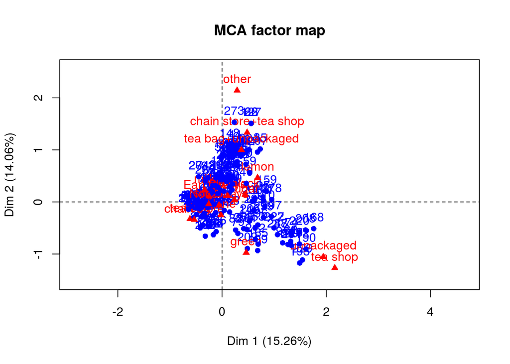

```r
plot(mca1)
```

…y ya…hay otras librerias pero creo que con esto es suficiente….

Haciendo análisis de correspondencias simples a partir dela tabla disyuntiva $Z$ usando la función CA de FactoMiner: primero generamos las funciones que calculan la matriz $Z$ y la matriz de Burt:

```r
dichotom <- function(data,out='numeric') {
  if(!is.data.frame(data)) data <- data.frame(data)
  res <- matrix(nrow=nrow(data),ncol=length(levels(data[,1])))
  for(i in 1:ncol(data)) {
    if(is.factor(data[,i])==FALSE) data[,i] <- factor(data[,i])
    nlevels <- length(levels(data[,i]))
    temp <- matrix(nrow=nrow(data),ncol=nlevels)
    for(j in 1:nlevels) temp[,j] <- ifelse(data[,i]==levels(data[,i])[j],1,0)
    colnames(temp) <- paste(names(data)[i],levels(data[,i]),sep=".")
    if(i==1) res <- temp else res <- cbind(res,temp)
  }
  res <- as.data.frame(res)
  if(out=='factor') for(i in 1:ncol(res)) res[,i] <- as.factor(res[,i])
  res
}

burt <- function(data) {
  disj <- dichotom(data,out='numeric')
  res <- as.matrix(t(disj)) %*% as.matrix(disj)
  return(res)
}
```

Creamos la matriz de 0’s y 1’s a partir de newtea…

```r
Z<-dichotom(newtea)
head(Z)
```

```
##   Tea.black Tea.Earl Grey Tea.green How.alone How.lemon How.milk How.other
## 1         1             0         0         1         0        0         0
## 2         1             0         0         0         0        1         0
## 3         0             1         0         1         0        0         0
## 4         0             1         0         1         0        0         0
## 5         0             1         0         1         0        0         0
## 6         0             1         0         1         0        0         0
##   how.tea bag how.tea bag+unpackaged how.unpackaged sugar.No.sugar
## 1           1                      0              0              0
## 2           1                      0              0              1
## 3           1                      0              0              1
## 4           1                      0              0              0
## 5           1                      0              0              1
## 6           1                      0              0              1
##   sugar.sugar where.chain store where.chain store+tea shop where.tea shop
## 1           1                 1                          0              0
## 2           0                 1                          0              0
## 3           0                 1                          0              0
## 4           1                 1                          0              0
## 5           0                 1                          0              0
## 6           0                 1                          0              0
##   always.always always.Not.always
## 1             0                 1
## 2             0                 1
## 3             0                 1
## 4             0                 1
## 5             1                 0
## 6             0                 1
```

hacemos el analisis de correspondencias simples a la matriz $Z$ y graficamos:

```r
res.ca<-CA(Z,graph = FALSE) #corresponcias simples para la matriz Z
res.ca
```

```
## **Results of the Correspondence Analysis (CA)**
## The row variable has  300  categories; the column variable has 17 categories
## The chi square of independence between the two variables is equal to 3300 (p-value =  1 ).
## *The results are available in the following objects:
##
##    name              description
## 1  "$eig"            "eigenvalues"
## 2  "$col"            "results for the columns"
## 3  "$col$coord"      "coord. for the columns"
## 4  "$col$cos2"       "cos2 for the columns"
## 5  "$col$contrib"    "contributions of the columns"
## 6  "$row"            "results for the rows"
## 7  "$row$coord"      "coord. for the rows"
## 8  "$row$cos2"       "cos2 for the rows"
## 9  "$row$contrib"    "contributions of the rows"
## 10 "$call"           "summary called parameters"
## 11 "$call$marge.col" "weights of the columns"
## 12 "$call$marge.row" "weights of the rows"
```

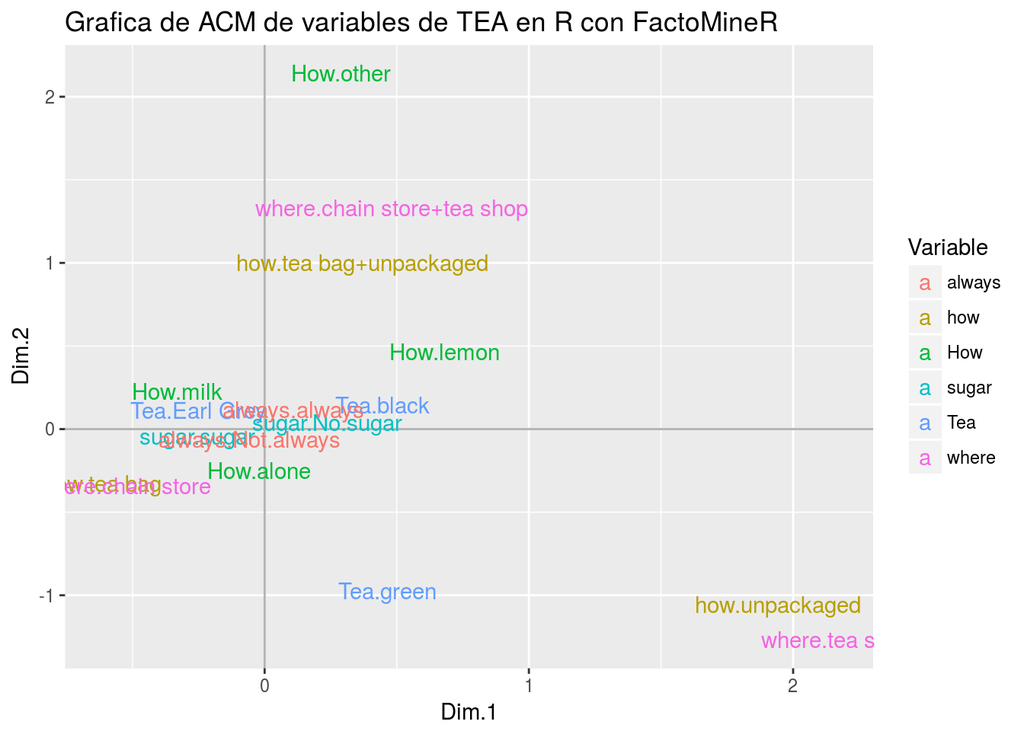

```r
#usamos el mismo codigo con el se grafico en MCA
# Graficamos con Data.Frame
mca1_vars_df = data.frame(res.ca$col$coord, Variable = rep(names(cats), #en vez de usar mca1$var$coord usamos res.ca$col$coord y abajo en vez de usar mca1$ind$coord usamos res.ca$row$coord
    cats))
mca1_obs_df = data.frame(res.ca$row$coord)

# Grafica de las categorias de las variables
ggplot(data = mca1_vars_df, aes(x = Dim.1, y = Dim.2, label = rownames(mca1_vars_df))) +
    geom_hline(yintercept = 0, colour = "gray70") + geom_vline(xintercept = 0,
    colour = "gray70") + geom_text(aes(colour = Variable)) + ggtitle("Grafica de ACM de variables de TEA en R con FactoMineR")
```

si comparamos la grafica con la obtenida de MCA es la misma entonces se prueba que ACM es lo mismo que hacer ACS en la matriz $Z$

con la matriz de BUrt ahora….

```r
B<-burt(newtea)
head(B)
```

```
##               Tea.black Tea.Earl Grey Tea.green How.alone How.lemon
## Tea.black            74             0         0        42         7
## Tea.Earl Grey         0           193         0       128        24
## Tea.green             0             0        33        25         2
## How.alone            42           128        25       195         0
## How.lemon             7            24         2         0        33
## How.milk             19            38         6         0         0
##               How.milk How.other how.tea bag how.tea bag+unpackaged
## Tea.black           19         6          36                     23
## Tea.Earl Grey       38         3         117                     60
## Tea.green            6         0          17                     11
## How.alone            0         0         108                     60
## How.lemon            0         0          16                     12
## How.milk            63         0          41                     18
##               how.unpackaged sugar.No.sugar sugar.sugar where.chain store
## Tea.black                 15             51          23                46
## Tea.Earl Grey             16             84         109               124
## Tea.green                  5             20          13                22
## How.alone                 27            109          86               137
## How.lemon                  5             12          21                12
## How.milk                   4             29          34                40
##               where.chain store+tea shop where.tea shop always.always
## Tea.black                             20              8            19
## Tea.Earl Grey                         55             14            74
## Tea.green                              3              8            10
## How.alone                             39             19            66
## How.lemon                             14              7            11
## How.milk                              19              4            23
##               always.Not.always
## Tea.black                    55
## Tea.Earl Grey               119
## Tea.green                    23
## How.alone                   129
## How.lemon                    22
## How.milk                     40
```

usando correspondencias simples al igual que el ejemplo anterior..

```r
res.ca<-CA(B,graph = FALSE) #corresponcias simples para la matriz Z
res.ca
```

```
## **Results of the Correspondence Analysis (CA)**
## The row variable has  17  categories; the column variable has 17 categories
## The chi square of independence between the two variables is equal to 3790.282 (p-value =  0 ).
## *The results are available in the following objects:
##
##    name              description
## 1  "$eig"            "eigenvalues"
## 2  "$col"            "results for the columns"
## 3  "$col$coord"      "coord. for the columns"
## 4  "$col$cos2"       "cos2 for the columns"
## 5  "$col$contrib"    "contributions of the columns"
## 6  "$row"            "results for the rows"
## 7  "$row$coord"      "coord. for the rows"
## 8  "$row$cos2"       "cos2 for the rows"
## 9  "$row$contrib"    "contributions of the rows"
## 10 "$call"           "summary called parameters"
## 11 "$call$marge.col" "weights of the columns"
## 12 "$call$marge.row" "weights of the rows"
```

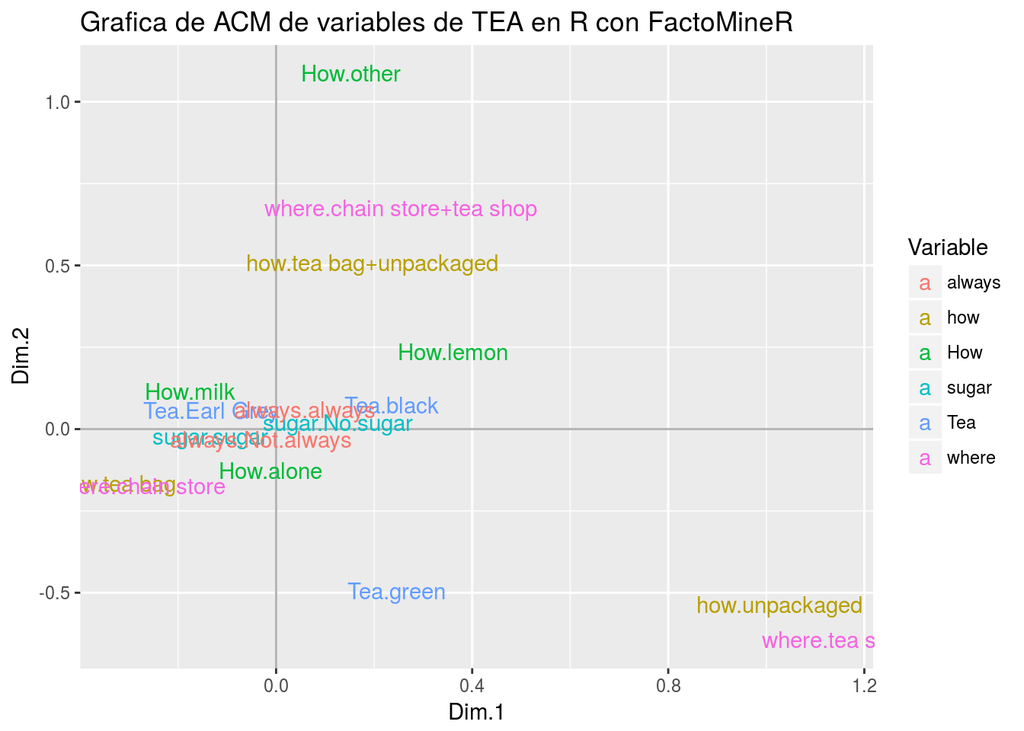

```r
#usamos el mismo codigo con el se grafico en MCA
# Graficamos con Data.Frame
mca1_vars_df = data.frame(res.ca$col$coord, Variable = rep(names(cats), #en vez de usar mca1$var$coord usamos res.ca$col$coord y abajo en vez de usar mca1$ind$coord usamos res.ca$row$coord
    cats))
mca1_obs_df = data.frame(res.ca$row$coord)

# Grafica de las categorias de las variables
ggplot(data = mca1_vars_df, aes(x = Dim.1, y = Dim.2, label = rownames(mca1_vars_df))) +
    geom_hline(yintercept = 0, colour = "gray70") + geom_vline(xintercept = 0,
    colour = "gray70") + geom_text(aes(colour = Variable)) + ggtitle("Grafica de ACM de variables de TEA en R con FactoMineR")
```

se obtiene la misma gráfica esto comprueba loque en la teoría en resumen se explica, la matriz de dummies $Z$ y la matriz de Burt $B$ haciéndoles análisis de correspondencias simples resulta lo mismo que hacer análisis de correspondencias múltiples a la tabla original newtea, sólo hay que mencionar que parael caso de la matriz de Burt los eigenvalores deben ajustarse ya que al hacer un perfil de filas y columnas y como la matriz de burt es simétrica se obtiene la misma información…